# Eleanor & Park

Author: Rainbow Rowell

**“What are the chances you’d ever meet someone like that? he wondered. Someone you could love forever, someone who would forever love you back? And what did you do when that person was born half a world away? The math seemed impossible.”**

― Rainbow Rowell, Eleanor & Park

[figure not shown]

## Summary

Two misfits. One extraordinary love.

Eleanor… Red hair, wrong clothes. Standing behind him until he turns his head. Lying beside him until he wakes up. Making everyone else seem drabber and flatter and never good enough…Eleanor.

Park… He knows she’ll love a song before he plays it for her. He laughs at her jokes before she ever gets to the punch line. There’s a place on his chest, just below his throat, that makes her want to keep promises…Park.

Set over the course of one school year, this is the story of two star-crossed sixteen-year-olds—smart enough to know that first love almost never lasts, but brave and desperate enough to try.

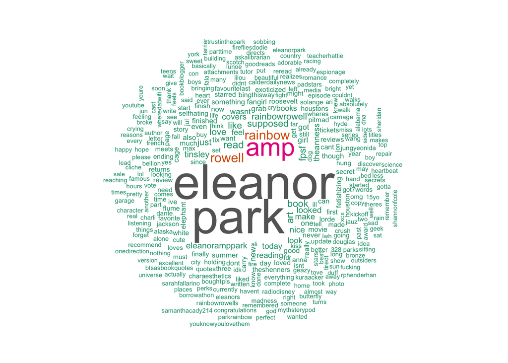

[output not shown]

[output not shown]

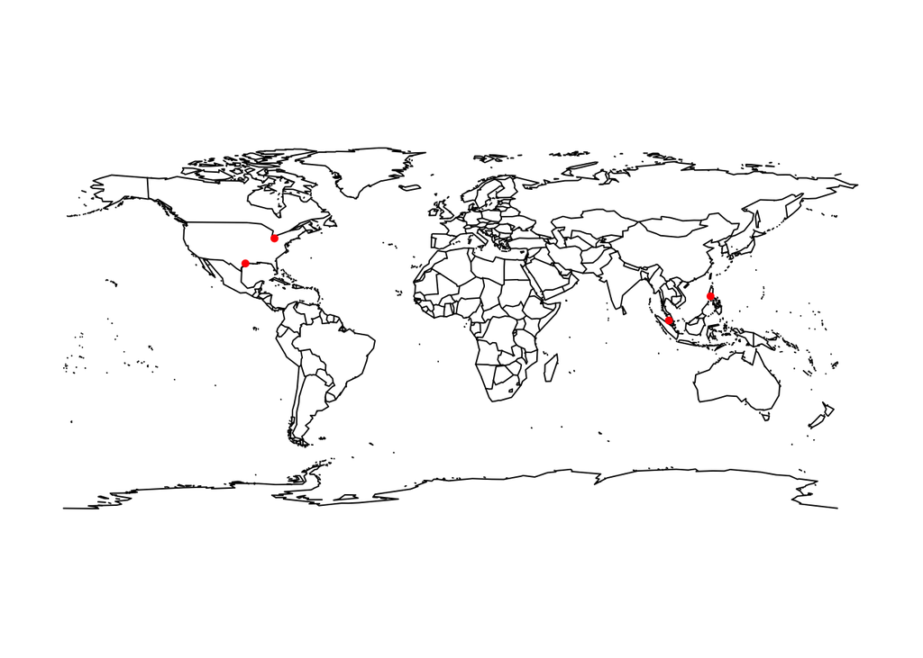

## Key Themes

- firstlove
- outcasts

## Extras

- A New York Times Best Seller!
- A 2014 Michael L. Printz Honor Book for Excellence in Young Adult Literature
- Eleanor & Park is the winner of the 2013 Boston Globe Horn Book Award for Best Fiction Book.
- A Publishers Weekly Best Children’s Book of 2013
- A New York Times Book Review Notable Children’s Book of 2013
- A Kirkus Reviews Best Teen Book of 2013
- An NPR Best Book of 2013

summary from Goodreads

extras from Barnes & Noble